# Function in R

## 제어문의 간단한 복습

### 1. for 문

for문은 () 괄호 안에 변수를 어떻게 반복할 지 알려준다.

```r
for(i in c(1:5,4:1)){
  cat(paste(rep("hello", i)), "\n")
  }
```

```
## hello
## hello hello
## hello hello hello
## hello hello hello hello
## hello hello hello hello hello
## hello hello hello hello
## hello hello hello
## hello hello
## hello
```

첫번째 줄의 i라는 변수가 1:5 그 다음에는 4:1로 변하도록 하였고,

rep()함수를 통해 “hello”가 i번 반복 출력되도록 만들었다.

cat()함수 대신 print를 사용해도 괜찮지만, 출력 결과는 약간 다르다. (“”은 필요 없다.)

```r
for(i in c(1:5,4:1)){
print(paste(rep("hello", i)))
  }
```

```
## [1] "hello"
## [1] "hello" "hello"
## [1] "hello" "hello" "hello"
## [1] "hello" "hello" "hello" "hello"
## [1] "hello" "hello" "hello" "hello" "hello"
## [1] "hello" "hello" "hello" "hello"
## [1] "hello" "hello" "hello"
## [1] "hello" "hello"
## [1] "hello"
```

### 2. while 문

while문은 괄호안의 조건이 참일 동안만 실행된다. 따라서 괄호안의 조건을 바꾸어주는 문장이 꼭 while문 안에 포함되어야 한다. 그렇지 않으면 무한적으로 while문이 실행된다.

```r
i=0
while(i <5){
  cat(paste(rep("hello", i)), "\n")
  i=i+1
  }
```

```
##
## hello
## hello hello
## hello hello hello
## hello hello hello hello
```

### 3. if-else 문

if의 조건이 ()안에 들어가고 그 만족할 때 실행되는 문장을 다음에 넣는다. 만약 if 조건이 만족하지 않는다면 else 문장이 실행되게 된다.

예) R을 이용한 동전던지기 (100번)

1. [0,1] 사이의 수 100개를 생성한다.
2. 숫자의 값이 0.5보다 작으면 “T” 그렇지 않으면 “H”로 한다.

```r
set.seed(123434)
x<-runif(100)
y <- ifelse(x<0.5,"T","H")
table(y)
```

```
## y
##  H  T
## 48 52
```

컴퓨터를 이용한 주사위 던지기를 500번 한다면?

1. [0,1] 사이의 수 500개를 생성한다.
2. 숫자의 값이 1/6보다 작으면 1, 2/6보다 작으면 2, 3/6보다 작으면 3, 4/6보다 작으면 4, 5/6보다 작으면 5, 그렇지 않으면 6으로 한다.

```r
set.seed(123434)
x<-runif(500)
y <- ifelse(x<1/6,1,
            ifelse(x<2/6,2,
                   ifelse(x<3/6,3,
                          ifelse(x<4/6,4,
                                 ifelse(x<5/6,5,6)))))
table(y)
```

```
## y
##  1  2  3  4  5  6
## 93 78 94 83 76 76
```

시뮬레이션을 통한 도박의 계산

승리 확률이 1/2인 도박이 있다.(예 동전던지기)

게임 참가비는 무제한인데, 승리하면 베팅한 금액의 2배를 벌고 그렇지 않으면 베팅금액을 잃는다.

승리공식으로 1을 베팅해서 이기면 1을 계속해서 배팅하고, 만약 지게되면 2배 베팅, 또 지면 4배 배팅, 또 지면 8배 비팅, 또 지면 16배 …. 배팅한다고 하자.

그러면 참여자는 돈을 정말 벌 수 있을까?

```r
set.seed(123434)

x<-runif(500)
y <- ifelse(x<0.5,"win","lose")
table(y)
```

```
## y
## lose  win
##  235  265
```

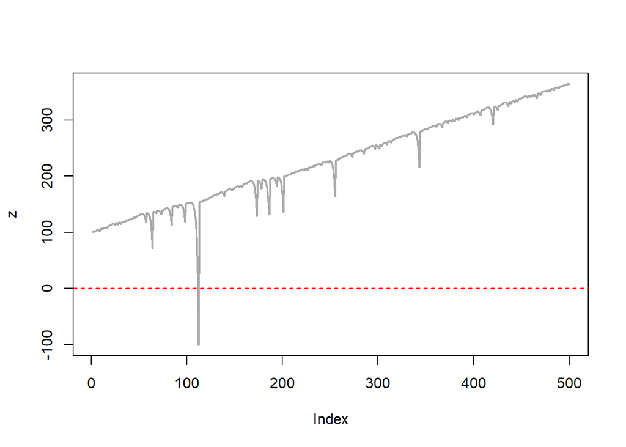

```r
z <- rep(0,500)

money=100

stack <- 0

for(i in 1:500){

  if(y[i] =="win") {
    money= money+2^stack
    stack=0
    z[i]=money
  } # end if win

  if(y[i] =="lose") {

    if(stack==0) {
      money= money-1
      z[i]=money
      stack=1
    } else {
      money= money-2^stack
      stack=stack+1
      z[i]=money
    } # end sub-if
  } # end if lose
} # end for i


plot(z, type="l", col="darkgrey", lwd=2)
abline(h=0, col="red", lty=2)
```

위의 그림은 자산이 100으로 시작했을때 500번 게임을 했을 때의 자산의 변화이다. 그림에서 보는 것처럼 110번 전후로 자산이 0보다 낮아지므로 파산하게 되어 돈을 벌 수 없다.

실제 도박경기에서 이길 확률은

첫째, 1/2보다 낮다. 예를 들어 이길 확률이 0.495

둘째, 최대 배팅금액이 정해져 있다. (무한히 베팅 할 수 없다.)

예를 들어 최대 베팅금액이 50으로 제한되어 있다면

```r
set.seed(123434)

iter=400

x<-runif(iter)
y <- ifelse(x<0.495,"win","lose")
table(y)
```

```
## y
## lose  win
##  187  213
```

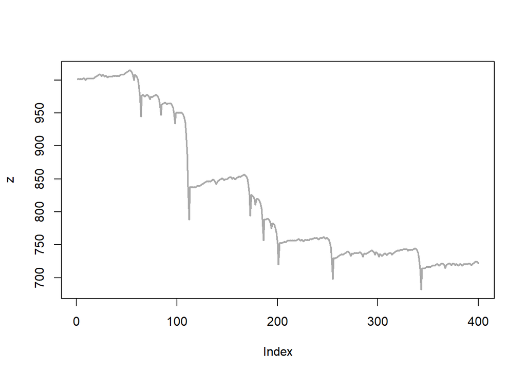

```r
z <- rep(0,iter)

money=1000
stack <- 0
bet= 2^stack

for(i in 1:iter){

  if(y[i] =="win") {
    if(bet>=50)  bet= 50
    money= money+bet

    z[i]=money
    stack=0
    bet= 2^stack
    } # end if win

  if(y[i] =="lose") {

    if(stack==0) {
      money= money-bet

      z[i]=money
      stack=1

    } else {
      bet= 2^stack
      if(bet >=50) bet=50

      money= money-bet

      z[i]=money

      stack=stack+1

      if(z[i]<0) break
    } # end sub-if
  } # end if lose
} # end for i

plot(z, type="l", col="darkgrey", lwd=2)
abline(h=0, col="red", lty=2)
```

- 위에 관련된 내용을 자세히 공부하고자 하는 학생은 3학년 2학기 *통계시뮬레이션* 과목을 수강하세요.

> 결론 : 도박하지 말자!!! 도박해서 성공하기는 정말 어렵다.

### 4. 나만의 함수 만들기.

R은 자신만의 사용자정의 함수를 만들어 쉽게 이용할 수 있다.

예를 들어 mysum(x, y, z)라는 함수를 만들어 z=1이면 x+y, z=2이면 x-y, z=3이면 x*y를 계산하고자 한다.

기본적인 함수의 형식은

> function_name <- function(arg1, arg2,…){

> statement1

> statement2

> …

> return(object)

> }

이다.

mysum을 예를 들어 만들면 아래와 같다.

```r
mysum <- function(x,y,z){
  if(z==1) return(x+y)
  if(z==2) return(x-y)
  if(z==3) return(x*y)
}

mysum(5,4,3)
```

```
## [1] 20
```

```r
mysum(12,19,1)
```

```
## [1] 31
```

```r
mysum(20,10,2)
```

```
## [1] 10
```

앞에서 다루었던 도박도 function으로 만들어보자. 승리확률, 초기자본, 시행횟 수 이렇게 3개릴 입력받아 그릴 수 있다.

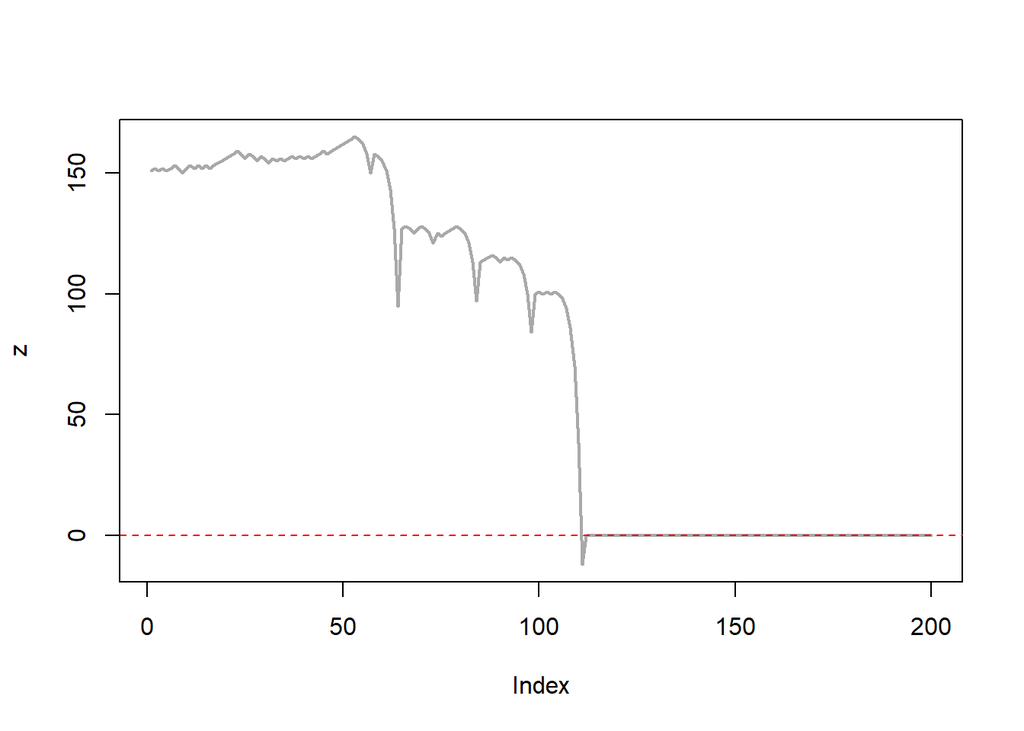

```r
coin.bet <- function(p, money, iter){

set.seed(123434)
x<-runif(iter)
y <- ifelse(x<p,"win","lose")
table(y)

z <- rep(0,iter)

money=money
stack <- 0
bet= 2^stack

for(i in 1:iter){

  if(y[i] =="win") {
    if(bet>=50)  bet= 50
    money= money+bet

    z[i]=money
    stack=0
    bet= 2^stack
    } # end if win

  if(y[i] =="lose") {

    if(stack==0) {
      money= money-bet

      z[i]=money
      stack=1

    } else {
      bet= 2^stack
      if(bet >=50) bet=50

      money= money-bet

      z[i]=money

      stack=stack+1

      if(z[i]<0) break
    } # end sub-if
  } # end if lose
} # end for i

plot(z, type="l", col="darkgrey", lwd=2)
abline(h=0, col="red", lty=2)
}

coin.bet(p=0.49,money=150,iter=200)
```

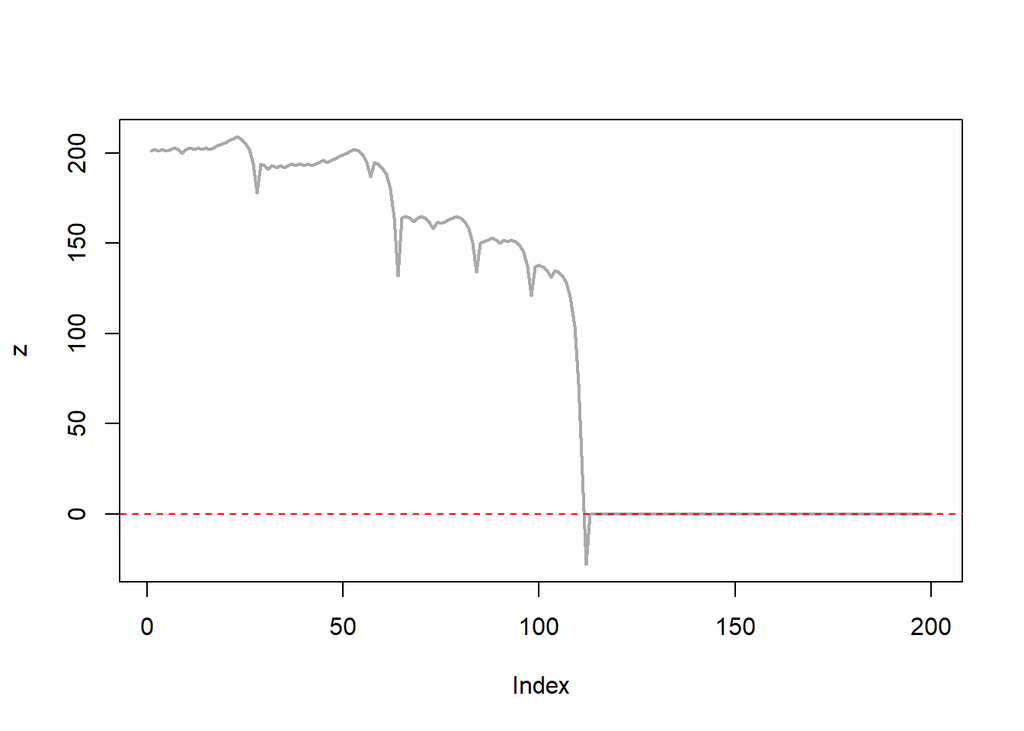

```r
coin.bet(p=0.48,money=200,iter=200)
```

Q1. 대구의 버스요금은 현금 이용시 성인 : 1250원(20살 이상), 청소년 900원(8살~19살), 어린이 500원(3살~7살), 영아 무료 (0~2살) 카드 이용시 위의 금액에서 10%할인된다.

함수를 만들어 나이(age)와 이용방법(type)에 따라 요금이 출력되는 함수를 만들어라.

```r
  daegu.bus <- function(age, type){
  if(type=="현금"){
    if(age>=20) fare=1250
    else if (age>=8) fare=900
    else if (age>=3) fare=500
    else fare=0

    print(paste("입력된 나이 :",age, "지불방법 : ", type, "지불금액: ",fare))
  } else if(type=="카드") {
    if(age>=20) fare=1250
    else if (age>=8) fare=900
    else if (age>=3) fare=500
    else fare=0
    fare=fare*0.9
    print(paste("입력된 나이 :",age, "지불방법 : ", type, "지불금액: ",fare))
  } else {
    print("type이 잘못 입력되었습니다.")
  }
}

daegu.bus(2,"현금")
```

```
## [1] "입력된 나이 : 2 지불방법 :  현금 지불금액:  0"
```

```r
daegu.bus(5,"현금")
```

```
## [1] "입력된 나이 : 5 지불방법 :  현금 지불금액:  500"
```

```r
daegu.bus(12,"현금")
```

```
## [1] "입력된 나이 : 12 지불방법 :  현금 지불금액:  900"
```

```r
daegu.bus(40,"현금")
```

```
## [1] "입력된 나이 : 40 지불방법 :  현금 지불금액:  1250"
```

```r
daegu.bus(2,"카드")
```

```
## [1] "입력된 나이 : 2 지불방법 :  카드 지불금액:  0"
```

```r
daegu.bus(5,"카드")
```

```
## [1] "입력된 나이 : 5 지불방법 :  카드 지불금액:  450"
```

```r
daegu.bus(12,"카드")
```

```
## [1] "입력된 나이 : 12 지불방법 :  카드 지불금액:  810"
```

```r
daegu.bus(40,"카드")
```

```
## [1] "입력된 나이 : 40 지불방법 :  카드 지불금액:  1125"
```

Q2. 마트를 이용하는데, 이용금액과 주차시간에 따라 주차비가 계산된다.

1. 30분 미만 무료
2. 30분 초과시 기본요금 1000원, 추가시간 10분당 200원씩 추가
3. 최대 요금은 10000원
4. 구매금액이 10000원이면 1시간 무료, 20000원이면 2시간무료, 30000원이면 3시간 무료이다.

주차시간과 구매금액을 입력하면 주차요금이 출력되는 함수를 만드세요.

```r
parking <- function(park_time, purchase){
  discount <- ifelse(purchase>=30000,180,
                     ifelse(purchase>=20000, 120,
                            ifelse(purchase>=10000, 60,0)))
  park_time=park_time-discount

  fare <- ifelse(park_time<30,0, 1000+floor((park_time-30)/10)*200)
  if(fare>=10000) fare=10000
  print(paste("주차요금은 :",fare,"입니다."))
  return(fare)
}

parking(350,30000)
```

```
## [1] "주차요금은 : 3800 입니다."
```

```
## [1] 3800
```

```r
parking(149,20000)
```

```
## [1] "주차요금은 : 0 입니다."
```

```
## [1] 0
```

```r
parking(123,10000)
```

```
## [1] "주차요금은 : 1600 입니다."
```

```
## [1] 1600
```

```r
parking(600,0)
```

```
## [1] "주차요금은 : 10000 입니다."
```

```
## [1] 10000
```

Q3. 섭씨온도를 화씨온도로 바꾸어주는 함수는? $화씨온도 =(섭씨온도 * 9/5)+32$

```r
fahrenheit <- function(x){
  y <- (x*9/5)+32
  return(y)
}

celcius =c(29,27,32,26,27.5,30,27)
fahrenheit(celcius)
```

```
## [1] 84.2 80.6 89.6 78.8 81.5 86.0 80.6
```

### 도전 : 부모의 키를 알면 자녀의 키를 예측할 수 있습니다.

```
아들의 예측키 = (아빠 키 + 엄마 키)/2 +6.5
딸의 예측키 = (아빠 키 + 엄마 키)/2 -6.5
```

위의 아빠키, 엄마키, 자녀를 입력하면 예측 키가 출력되는 함수를 만드세요.

```r
pred.h(dad=178, mom=175, 1) # 아빠 178, 엄마=175, 아들
```

```
## 아들의 예측키는  183 cm입니다.
```

```r
pred.h(dad=171, mom=188, 2) # 아빠 178, 엄마=175, 아들
```

```
## 딸의 예측키는  173 cm입니다.
```

```r
pred.h(dad=207, mom=158, 1) # 아빠 178, 엄마=175, 아들
```

```
## 아들의 예측키는  189 cm입니다.
```